# AI-CA0-F01

```python
import pandas as pd
import matplotlib.pyplot as plt
import numpy as np
import time as t
from scipy.stats import norm
from scipy import stats
```

```python
titanic = pd.read_csv('train.csv')
titanic
```

|  | PassengerId | Survived | Pclass | Name | Sex | Age | SibSp | Parch | Ticket | Fare | Cabin | Embarked |
| --- | --- | --- | --- | --- | --- | --- | --- | --- | --- | --- | --- | --- |
| 0 | 1 | 0 | 3 | Braund, Mr. Owen Harris | male | 22.0 | 1 | 0 | A/5 21171 | 7.2500 | NaN | S |
| 1 | 2 | 1 | 1 | Cumings, Mrs. John Bradley (Florence Briggs Th... | female | 38.0 | 1 | 0 | PC 17599 | 71.2833 | C85 | C |
| 2 | 3 | 1 | 3 | Heikkinen, Miss. Laina | female | 26.0 | 0 | 0 | STON/O2. 3101282 | 7.9250 | NaN | S |
| 3 | 4 | 1 | 1 | Futrelle, Mrs. Jacques Heath (Lily May Peel) | female | 35.0 | 1 | 0 | 113803 | 53.1000 | C123 | S |
| 4 | 5 | 0 | 3 | Allen, Mr. William Henry | male | 35.0 | 0 | 0 | 373450 | 8.0500 | NaN | S |
| ... | ... | ... | ... | ... | ... | ... | ... | ... | ... | ... | ... | ... |
| 886 | 887 | 0 | 2 | Montvila, Rev. Juozas | male | 27.0 | 0 | 0 | 211536 | 13.0000 | NaN | S |
| 887 | 888 | 1 | 1 | Graham, Miss. Margaret Edith | female | 19.0 | 0 | 0 | 112053 | 30.0000 | B42 | S |
| 888 | 889 | 0 | 3 | Johnston, Miss. Catherine Helen "Carrie" | female | NaN | 1 | 2 | W./C. 6607 | 23.4500 | NaN | S |
| 889 | 890 | 1 | 1 | Behr, Mr. Karl Howell | male | 26.0 | 0 | 0 | 111369 | 30.0000 | C148 | C |
| 890 | 891 | 0 | 3 | Dooley, Mr. Patrick | male | 32.0 | 0 | 0 | 370376 | 7.7500 | NaN | Q |

891 rows × 12 columns

```python
titanic.describe()
```

|  | PassengerId | Survived | Pclass | Age | SibSp | Parch | Fare |
| --- | --- | --- | --- | --- | --- | --- | --- |
| count | 891.000000 | 891.000000 | 891.000000 | 714.000000 | 891.000000 | 891.000000 | 891.000000 |
| mean | 446.000000 | 0.383838 | 2.308642 | 29.699118 | 0.523008 | 0.381594 | 32.204208 |
| std | 257.353842 | 0.486592 | 0.836071 | 14.526497 | 1.102743 | 0.806057 | 49.693429 |
| min | 1.000000 | 0.000000 | 1.000000 | 0.420000 | 0.000000 | 0.000000 | 0.000000 |
| 25% | 223.500000 | 0.000000 | 2.000000 | 20.125000 | 0.000000 | 0.000000 | 7.910400 |
| 50% | 446.000000 | 0.000000 | 3.000000 | 28.000000 | 0.000000 | 0.000000 | 14.454200 |
| 75% | 668.500000 | 1.000000 | 3.000000 | 38.000000 | 1.000000 | 0.000000 | 31.000000 |
| max | 891.000000 | 1.000000 | 3.000000 | 80.000000 | 8.000000 | 6.000000 | 512.329200 |

```python
titanic.tail(10)
```

|  | PassengerId | Survived | Pclass | Name | Sex | Age | SibSp | Parch | Ticket | Fare | Cabin | Embarked |
| --- | --- | --- | --- | --- | --- | --- | --- | --- | --- | --- | --- | --- |
| 881 | 882 | 0 | 3 | Markun, Mr. Johann | male | 33.0 | 0 | 0 | 349257 | 7.8958 | NaN | S |
| 882 | 883 | 0 | 3 | Dahlberg, Miss. Gerda Ulrika | female | 22.0 | 0 | 0 | 7552 | 10.5167 | NaN | S |
| 883 | 884 | 0 | 2 | Banfield, Mr. Frederick James | male | 28.0 | 0 | 0 | C.A./SOTON 34068 | 10.5000 | NaN | S |
| 884 | 885 | 0 | 3 | Sutehall, Mr. Henry Jr | male | 25.0 | 0 | 0 | SOTON/OQ 392076 | 7.0500 | NaN | S |
| 885 | 886 | 0 | 3 | Rice, Mrs. William (Margaret Norton) | female | 39.0 | 0 | 5 | 382652 | 29.1250 | NaN | Q |
| 886 | 887 | 0 | 2 | Montvila, Rev. Juozas | male | 27.0 | 0 | 0 | 211536 | 13.0000 | NaN | S |
| 887 | 888 | 1 | 1 | Graham, Miss. Margaret Edith | female | 19.0 | 0 | 0 | 112053 | 30.0000 | B42 | S |
| 888 | 889 | 0 | 3 | Johnston, Miss. Catherine Helen "Carrie" | female | NaN | 1 | 2 | W./C. 6607 | 23.4500 | NaN | S |
| 889 | 890 | 1 | 1 | Behr, Mr. Karl Howell | male | 26.0 | 0 | 0 | 111369 | 30.0000 | C148 | C |
| 890 | 891 | 0 | 3 | Dooley, Mr. Patrick | male | 32.0 | 0 | 0 | 370376 | 7.7500 | NaN | Q |

The default tail shows the last 5 rows. When you put x in its argument, it shows the x last rows.

```python
titanic.head(2)
```

|  | PassengerId | Survived | Pclass | Name | Sex | Age | SibSp | Parch | Ticket | Fare | Cabin | Embarked |
| --- | --- | --- | --- | --- | --- | --- | --- | --- | --- | --- | --- | --- |
| 0 | 1 | 0 | 3 | Braund, Mr. Owen Harris | male | 22.0 | 1 | 0 | A/5 21171 | 7.2500 | NaN | S |
| 1 | 2 | 1 | 1 | Cumings, Mrs. John Bradley (Florence Briggs Th... | female | 38.0 | 1 | 0 | PC 17599 | 71.2833 | C85 | C |

The default head shows the first 5 rows. When you put x in its argument, it shows the x first rows.

```python
titanic.info()
```

```
<class 'pandas.core.frame.DataFrame'>
RangeIndex: 891 entries, 0 to 890
Data columns (total 12 columns):
 #   Column       Non-Null Count  Dtype
---  ------       --------------  -----
 0   PassengerId  891 non-null    int64
 1   Survived     891 non-null    int64
 2   Pclass       891 non-null    int64
 3   Name         891 non-null    object
 4   Sex          891 non-null    object
 5   Age          714 non-null    float64
 6   SibSp        891 non-null    int64
 7   Parch        891 non-null    int64
 8   Ticket       891 non-null    object
 9   Fare         891 non-null    float64
 10  Cabin        204 non-null    object
 11  Embarked     889 non-null    object
dtypes: float64(2), int64(5), object(5)
memory usage: 83.7+ KB
```

Info shows us various information, such as the number of rows and columns, column names, how many non-null elements in a column we have, the type of a column, the number of types and the memory amount used.

```python
titanic['Sex'] = titanic['Sex'].astype('category')
titanic['Sex'] = titanic['Sex'].cat.codes
titanic['Embarked'] = titanic['Embarked'].astype('category')
titanic['Embarked'] = titanic['Embarked'].cat.codes
titanic
```

|  | PassengerId | Survived | Pclass | Name | Sex | Age | SibSp | Parch | Ticket | Fare | Cabin | Embarked |
| --- | --- | --- | --- | --- | --- | --- | --- | --- | --- | --- | --- | --- |
| 0 | 1 | 0 | 3 | Braund, Mr. Owen Harris | 1 | 22.0 | 1 | 0 | A/5 21171 | 7.2500 | NaN | 2 |
| 1 | 2 | 1 | 1 | Cumings, Mrs. John Bradley (Florence Briggs Th... | 0 | 38.0 | 1 | 0 | PC 17599 | 71.2833 | C85 | 0 |
| 2 | 3 | 1 | 3 | Heikkinen, Miss. Laina | 0 | 26.0 | 0 | 0 | STON/O2. 3101282 | 7.9250 | NaN | 2 |
| 3 | 4 | 1 | 1 | Futrelle, Mrs. Jacques Heath (Lily May Peel) | 0 | 35.0 | 1 | 0 | 113803 | 53.1000 | C123 | 2 |
| 4 | 5 | 0 | 3 | Allen, Mr. William Henry | 1 | 35.0 | 0 | 0 | 373450 | 8.0500 | NaN | 2 |
| ... | ... | ... | ... | ... | ... | ... | ... | ... | ... | ... | ... | ... |
| 886 | 887 | 0 | 2 | Montvila, Rev. Juozas | 1 | 27.0 | 0 | 0 | 211536 | 13.0000 | NaN | 2 |
| 887 | 888 | 1 | 1 | Graham, Miss. Margaret Edith | 0 | 19.0 | 0 | 0 | 112053 | 30.0000 | B42 | 2 |
| 888 | 889 | 0 | 3 | Johnston, Miss. Catherine Helen "Carrie" | 0 | NaN | 1 | 2 | W./C. 6607 | 23.4500 | NaN | 2 |
| 889 | 890 | 1 | 1 | Behr, Mr. Karl Howell | 1 | 26.0 | 0 | 0 | 111369 | 30.0000 | C148 | 0 |
| 890 | 891 | 0 | 3 | Dooley, Mr. Patrick | 1 | 32.0 | 0 | 0 | 370376 | 7.7500 | NaN | 1 |

891 rows × 12 columns

Since both Sex and Embarked are categories (that won't be deleted later on) we encoded them as numbers for future usage.

According to our label encoding, Men = 1, Women = 0, Southampton = 2, Queenstown = 1, Cherbourg = 0.

```python
age_mean = titanic["Age"].mean()
titanic["Age"] = titanic["Age"].fillna(age_mean)
titanic = titanic.drop(["Cabin"], axis=1)
titanic.info()
titanic
```

```
<class 'pandas.core.frame.DataFrame'>
RangeIndex: 891 entries, 0 to 890
Data columns (total 11 columns):
 #   Column       Non-Null Count  Dtype
---  ------       --------------  -----
 0   PassengerId  891 non-null    int64
 1   Survived     891 non-null    int64
 2   Pclass       891 non-null    int64
 3   Name         891 non-null    object
 4   Sex          891 non-null    int8
 5   Age          891 non-null    float64
 6   SibSp        891 non-null    int64
 7   Parch        891 non-null    int64
 8   Ticket       891 non-null    object
 9   Fare         891 non-null    float64
 10  Embarked     891 non-null    int8
dtypes: float64(2), int64(5), int8(2), object(2)
memory usage: 64.5+ KB
```

|  | PassengerId | Survived | Pclass | Name | Sex | Age | SibSp | Parch | Ticket | Fare | Embarked |
| --- | --- | --- | --- | --- | --- | --- | --- | --- | --- | --- | --- |
| 0 | 1 | 0 | 3 | Braund, Mr. Owen Harris | 1 | 22.000000 | 1 | 0 | A/5 21171 | 7.2500 | 2 |
| 1 | 2 | 1 | 1 | Cumings, Mrs. John Bradley (Florence Briggs Th... | 0 | 38.000000 | 1 | 0 | PC 17599 | 71.2833 | 0 |
| 2 | 3 | 1 | 3 | Heikkinen, Miss. Laina | 0 | 26.000000 | 0 | 0 | STON/O2. 3101282 | 7.9250 | 2 |
| 3 | 4 | 1 | 1 | Futrelle, Mrs. Jacques Heath (Lily May Peel) | 0 | 35.000000 | 1 | 0 | 113803 | 53.1000 | 2 |
| 4 | 5 | 0 | 3 | Allen, Mr. William Henry | 1 | 35.000000 | 0 | 0 | 373450 | 8.0500 | 2 |
| ... | ... | ... | ... | ... | ... | ... | ... | ... | ... | ... | ... |
| 886 | 887 | 0 | 2 | Montvila, Rev. Juozas | 1 | 27.000000 | 0 | 0 | 211536 | 13.0000 | 2 |
| 887 | 888 | 1 | 1 | Graham, Miss. Margaret Edith | 0 | 19.000000 | 0 | 0 | 112053 | 30.0000 | 2 |
| 888 | 889 | 0 | 3 | Johnston, Miss. Catherine Helen "Carrie" | 0 | 29.699118 | 1 | 2 | W./C. 6607 | 23.4500 | 2 |
| 889 | 890 | 1 | 1 | Behr, Mr. Karl Howell | 1 | 26.000000 | 0 | 0 | 111369 | 30.0000 | 0 |
| 890 | 891 | 0 | 3 | Dooley, Mr. Patrick | 1 | 32.000000 | 0 | 0 | 370376 | 7.7500 | 1 |

891 rows × 11 columns

We replaced NaN ages with the mean of all ages, and we removed the cabin column as most of it were NaN and thus were useless. The advantages of replacing null numbers with the mean are that if the data is small, our accuracy won't decrease by a lot and fixes our data loss. The disatvantages are that if the mean is too far from what the NaN numbers were, then our new numbers will be very off from reality.

```python
titanic = titanic.drop(["Name", "Ticket", "PassengerId"], axis=1)
titanic
```

|  | Survived | Pclass | Sex | Age | SibSp | Parch | Fare | Embarked |
| --- | --- | --- | --- | --- | --- | --- | --- | --- |
| 0 | 0 | 3 | 1 | 22.000000 | 1 | 0 | 7.2500 | 2 |
| 1 | 1 | 1 | 0 | 38.000000 | 1 | 0 | 71.2833 | 0 |
| 2 | 1 | 3 | 0 | 26.000000 | 0 | 0 | 7.9250 | 2 |
| 3 | 1 | 1 | 0 | 35.000000 | 1 | 0 | 53.1000 | 2 |
| 4 | 0 | 3 | 1 | 35.000000 | 0 | 0 | 8.0500 | 2 |
| ... | ... | ... | ... | ... | ... | ... | ... | ... |
| 886 | 0 | 2 | 1 | 27.000000 | 0 | 0 | 13.0000 | 2 |
| 887 | 1 | 1 | 0 | 19.000000 | 0 | 0 | 30.0000 | 2 |
| 888 | 0 | 3 | 0 | 29.699118 | 1 | 2 | 23.4500 | 2 |
| 889 | 1 | 1 | 1 | 26.000000 | 0 | 0 | 30.0000 | 0 |
| 890 | 0 | 3 | 1 | 32.000000 | 0 | 0 | 7.7500 | 1 |

891 rows × 8 columns

Since these 3 columns all had unique in each row, they wouldn't really help us with our analyzation of the data. So it's best to remove them.

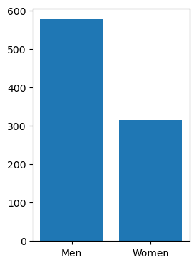

```
Men: 577 Women: 314
```

```python
men = titanic.loc[titanic["Sex"] == 1].count()[0]
women = titanic.loc[titanic["Sex"] == 0].count()[0]
names = ['Men', 'Women']
values = [men, women]
plt.figure(figsize=(30, 40))
plt.subplot(891)
plt.bar(names, values)
plt.show()
print("Men:",men,"Women:",women)
```

Reminder: according to our label encoding, Men = 1, Women = 0, Southampton = 2, Queenstown = 1, Cherbourg = 0.

```python
men = titanic.loc[titanic["Sex"] == 1]
southampton_men =  men.loc[men["Embarked"] == 2].count()[0]
print("Number of passengers who are Southampton men:", southampton_men)
```

```
Number of passengers who are Southampton men: 441
```

```python
over35 = titanic.loc[titanic["Age"] > 35]
over35_alone1 =  over35.loc[over35["SibSp"] == 0]
over35_alone2 =  over35_alone1.loc[over35_alone1["Parch"] == 0]
over35_alone_ticket3 = over35_alone2.loc[over35_alone2["Pclass"] == 3].count()[0]
print("Number of passengers who are over 35, alone, and have a type 3 Ticket:", over35_alone_ticket3)
```

```
Number of passengers who are over 35, alone, and have a type 3 Ticket: 41
```

```python
starting_time = t.time()
queenstown =  titanic.loc[titanic["Embarked"] == 1]
fare_queenstown = queenstown["Fare"].mean()
ending_time = t.time()
execution_time = (ending_time - starting_time) * 1000
print("Average fare of passengers embarked from Queenstown:",fare_queenstown,"\nExecution time:", execution_time, "milliseconds")
```

```
Average fare of passengers embarked from Queenstown: 13.276029870129872
Execution time: 2.0024776458740234 milliseconds
```

```python
starting_time1 = t.time()
queenstown1 =  titanic.loc[titanic["Embarked"] == 1]
num_of_queenstown = queenstown1.count()[0]
sum_fare = 0
for i in (queenstown1['Fare']):
    sum_fare += i
mean_fare = sum_fare / num_of_queenstown
ending_time1 = t.time()
execution_time1 = (ending_time1 - starting_time1) * 1000
print("Average fare of passengers embarked from Queenstown:",mean_fare,"\nExecution time:", execution_time1, "milliseconds")
```

```
Average fare of passengers embarked from Queenstown: 13.276029870129872
Execution time: 4.00233268737793 milliseconds
```

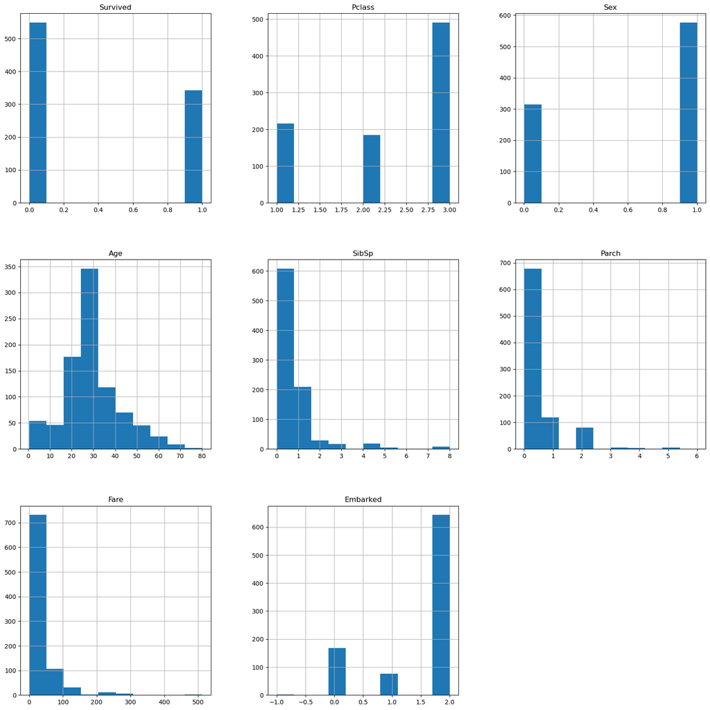

```python
titanic_hist = titanic.hist(figsize=(20, 20))
```

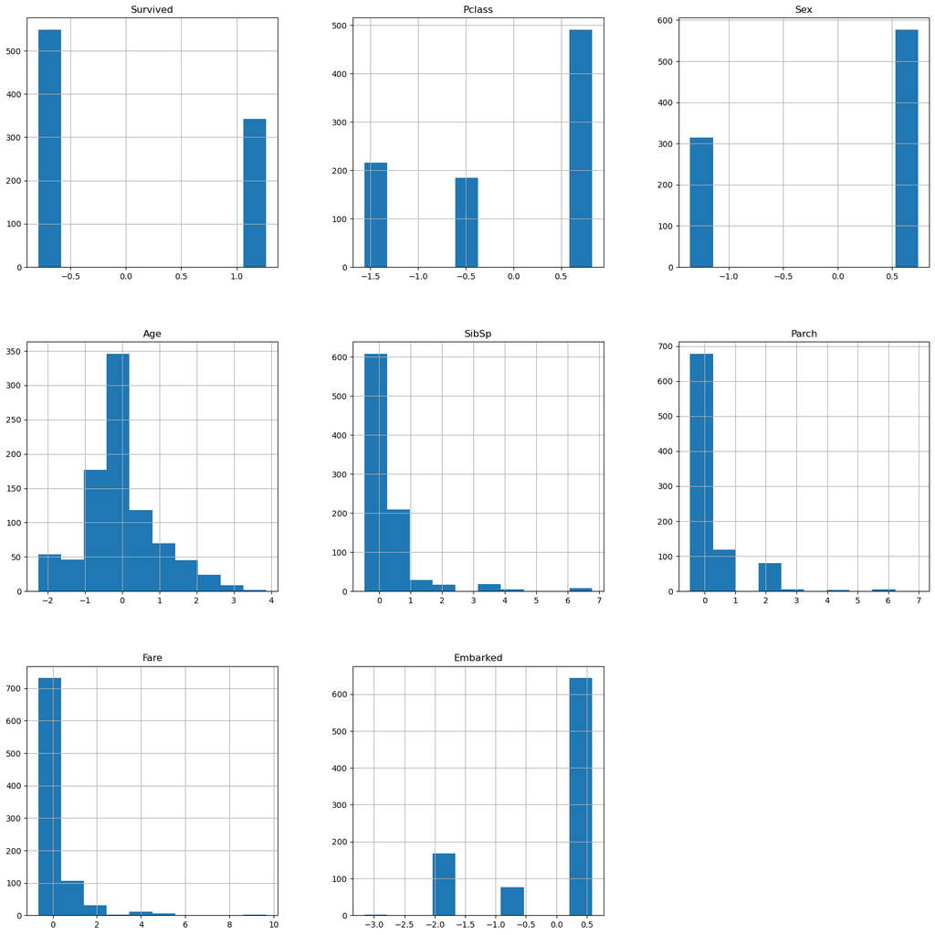

```python
normalized_titanic = (titanic - titanic.mean()) / titanic.std()
normalized_titanic_hist = normalized_titanic.hist(figsize=(20, 20))
```

```python
def comparisonPdf(survivor_mean, survivor_std, dead_mean, dead_std, column_name):
    x = np.linspace(survivor_mean - (3 * survivor_std), survivor_mean + (3 * survivor_std), 100)
    plt.plot(x, stats.norm.pdf(x,survivor_mean, survivor_std))
    y = np.linspace(dead_mean - (3 * dead_std), dead_mean + (3 * dead_std), 100)
    plt.plot(y, stats.norm.pdf(y,dead_mean, dead_std))
    plt.legend(["Survived", "Died"], loc = 'upper left')
    plt.title(f'Survivor vs Dead {column_name} Comparison')
    plt.show()
```

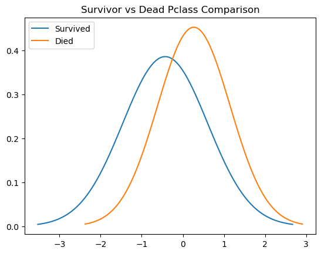

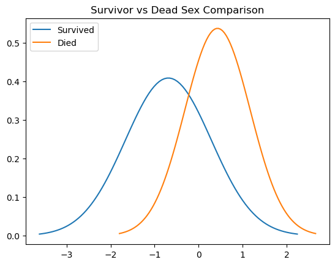

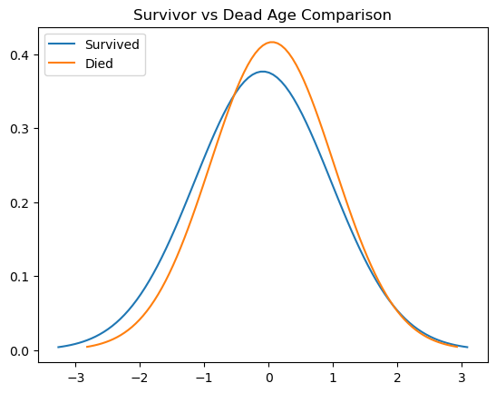

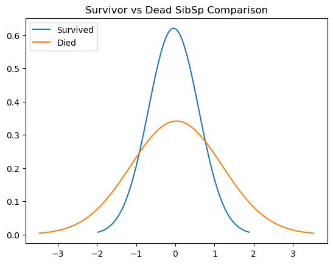

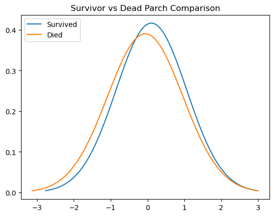

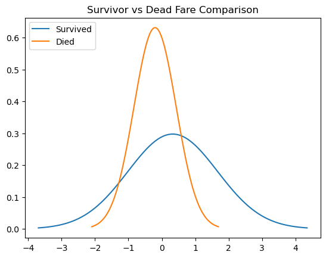

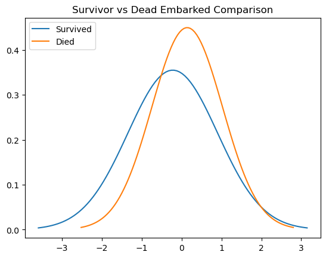

```python
survivor = normalized_titanic.loc[titanic["Survived"] == 1]
survivor_mean = survivor.mean()
survivor_std = survivor.std()
dead = normalized_titanic.loc[titanic["Survived"] == 0]
dead_mean = dead.mean()
dead_std = dead.std()

comparisonPdf(survivor_mean["Pclass"], survivor_std["Pclass"], dead_mean["Pclass"], dead_std["Pclass"], "Pclass")
comparisonPdf(survivor_mean["Sex"], survivor_std["Sex"], dead_mean["Sex"], dead_std["Sex"], "Sex")
comparisonPdf(survivor_mean["Age"], survivor_std["Age"], dead_mean["Age"], dead_std["Age"], "Age")
comparisonPdf(survivor_mean["SibSp"], survivor_std["SibSp"], dead_mean["SibSp"], dead_std["SibSp"], "SibSp")
comparisonPdf(survivor_mean["Parch"], survivor_std["Parch"], dead_mean["Parch"], dead_std["Parch"], "Parch")
comparisonPdf(survivor_mean["Fare"], survivor_std["Fare"], dead_mean["Fare"], dead_std["Fare"], "Fare")
comparisonPdf(survivor_mean["Embarked"], survivor_std["Embarked"], dead_mean["Embarked"], dead_std["Embarked"], "Embarked")
```

The best predictor has the biggest difference between the two curve's means, lowest variance, and the least amount of area covered between the two curves.

Therefore sex is the best predictor based on these three characteristics.

```python
def predictor(sex):
    survived = stats.norm.pdf(sex,survivor_mean["Sex"], survivor_std["Sex"])
    dead = stats.norm.pdf(sex,dead_mean["Sex"], dead_std["Sex"])
    if survived > dead:
        return 'yes'
    else:
        return 'no'
```

```python
test = pd.read_csv('test.csv')
test['Sex'] = test['Sex'].astype('category')
test['Sex'] = test['Sex'].cat.codes
test['Sex'] = test['Sex'].astype(float)
test["Survived"] = test['Sex'].apply(predictor)
test
```

|  | PassengerId | Pclass | Name | Sex | Age | SibSp | Parch | Ticket | Fare | Cabin | Embarked | Survived |
| --- | --- | --- | --- | --- | --- | --- | --- | --- | --- | --- | --- | --- |
| 0 | 892 | 3 | Kelly, Mr. James | 1.0 | 34.5 | 0 | 0 | 330911 | 7.8292 | NaN | Q | yes |
| 1 | 893 | 3 | Wilkes, Mrs. James (Ellen Needs) | 0.0 | 47.0 | 1 | 0 | 363272 | 7.0000 | NaN | S | no |
| 2 | 894 | 2 | Myles, Mr. Thomas Francis | 1.0 | 62.0 | 0 | 0 | 240276 | 9.6875 | NaN | Q | yes |
| 3 | 895 | 3 | Wirz, Mr. Albert | 1.0 | 27.0 | 0 | 0 | 315154 | 8.6625 | NaN | S | yes |
| 4 | 896 | 3 | Hirvonen, Mrs. Alexander (Helga E Lindqvist) | 0.0 | 22.0 | 1 | 1 | 3101298 | 12.2875 | NaN | S | no |
| ... | ... | ... | ... | ... | ... | ... | ... | ... | ... | ... | ... | ... |
| 413 | 1305 | 3 | Spector, Mr. Woolf | 1.0 | NaN | 0 | 0 | A.5. 3236 | 8.0500 | NaN | S | yes |
| 414 | 1306 | 1 | Oliva y Ocana, Dona. Fermina | 0.0 | 39.0 | 0 | 0 | PC 17758 | 108.9000 | C105 | C | no |
| 415 | 1307 | 3 | Saether, Mr. Simon Sivertsen | 1.0 | 38.5 | 0 | 0 | SOTON/O.Q. 3101262 | 7.2500 | NaN | S | yes |
| 416 | 1308 | 3 | Ware, Mr. Frederick | 1.0 | NaN | 0 | 0 | 359309 | 8.0500 | NaN | S | yes |
| 417 | 1309 | 3 | Peter, Master. Michael J | 1.0 | NaN | 1 | 1 | 2668 | 22.3583 | NaN | C | yes |

418 rows × 12 columns

```python
survivor_count =  test.loc[test["Survived"] == 'yes'].count()[0]
print("Number of survivors:", survivor_count)
```

```
Number of survivors: 266
```

```python
test['Survived'] = test['Survived'].astype('category')
test['Survived'] = test['Survived'].cat.codes

test
```

[output not shown]

418 rows × 12 columns

Making it similar to train.csv here

Reminder: Men = 1, Women = 0

```python
test.to_csv('prediction.csv', index=False)
```